# 統計学2

標本分布を理解する

矢内 勇生

2018-05-07（改訂: 2019-05-14, 2019-05-23, 2020-08-29）

## 準備

必要なパッケージを読み込む。

```r
library(tidyverse)
```

次に、日本語が正しく表示されるようにする。

**Linuxユーザのみ**次のコードを実行する。（IPAexフォントがインストールされていることを前提とする。）

```r
theme_set(theme_gray(base_size = 10, base_family = "IPAexGothic")) # Linux
```

**Macユーザのみ**次のコードを実行する。

```r
theme_set(theme_gray(base_size = 10, base_family = "HiraginoSans-W3")) # macOS
```

**Windowsユーザのみ**次のコードを実行する。

```r
theme_set(theme_gray(base_size = 10, base_family = "Japan1GothicBBB")) # Windows
```

## 標本分布のシミュレーション

### シミュレーション問題の設定

母集団（成人男性全体）では、平均身長が170cm、身長の標準偏差が5.5cm であり、身長は正規分布に従うことを知っているとする。

```r
mu <- 170     # 母平均
sigma <- 5.5  # 母標準偏差
```

以下では、様々な標本サイズで標本を抽出し、その標本の平均身長を求める作業を 1万回ずつ繰り返すことにする。

```r
n_sims <- 10^4  # シミュレーションの繰り返し回数
```

### 標本サイズ ($N$) が1のとき

標本サイズ $N = 1$ で標本を抽出し、標本平均を計算することを10^{4} 回`n_sims` 回）繰り返す。 まず、$N$ を設定する。

```r
N <- 1
```

1回の標本抽出は、

```r
h <- rnorm(N, mean = mu, sd = sigma)
```

で行える。 標本平均は、

```r
mean(h)
```

```
## [1] 163.1939
```

である。 これを1万回繰り返せばよい。

（本当はもっと簡単な方法もあるが） forループを使ってシミュレーションを実行してみよう。

まず、結果を保存するために、10^{4} 個の値を保存する容器（ベクトル）を用意する。要素（中身）は `NA` にしておく。

```r
sim_1 <- rep(NA, n_sims)
```

シミュレーションを実行する準備が整ったので、`for`ループでシミュレーションを実行する。（`for`ループ以外で実行する方法を知っている者は、その方法を利用してよい。）

```r
for (i in 1:n_sims) {
  h <- rnorm(N, mean = mu, sd = sigma)
  sim_1[i] <- mean(h)
}
```

結果をヒストグラムにしてみよう。

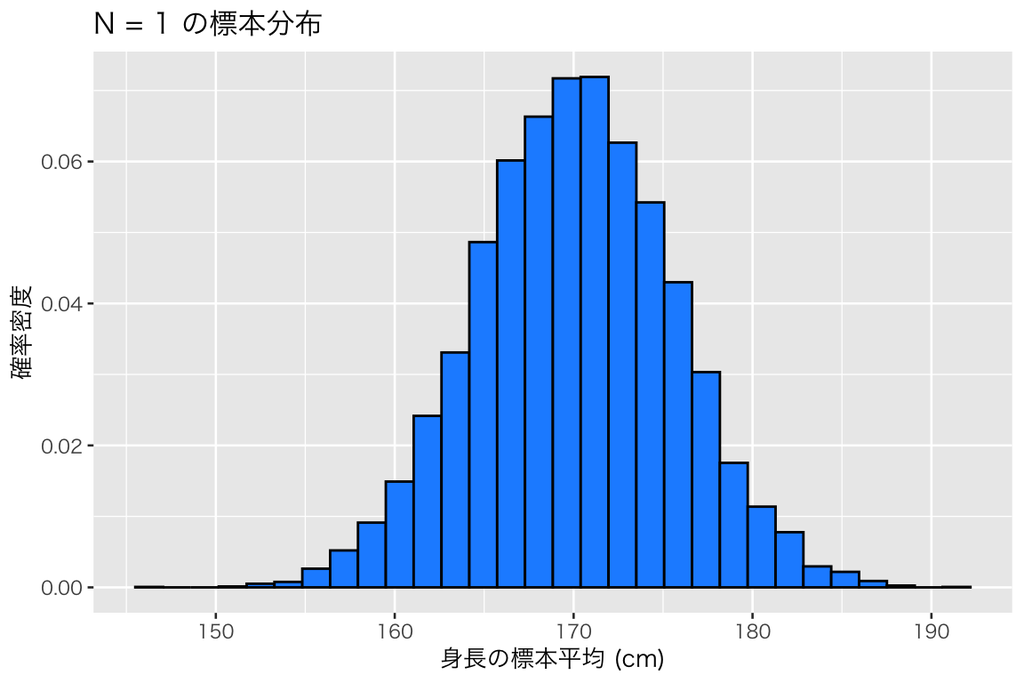

```r
df1 <- tibble(sim_1)
hist1 <- ggplot(df1, aes(x = sim_1, y = after_stat(density))) +
  geom_histogram(color = "black", fill = "dodgerblue") +
  labs(x = "身長の標本平均 (cm)",
       y = "確率密度",
       title = "N = 1 の標本分布")
plot(hist1)
```

このヒストグラムに、平均 170、標準偏差 5.5 の正規分布 ($\mbox{N}(170, 5.5)$ と表記する) の確率密度曲線を重ね書きしてみよう。

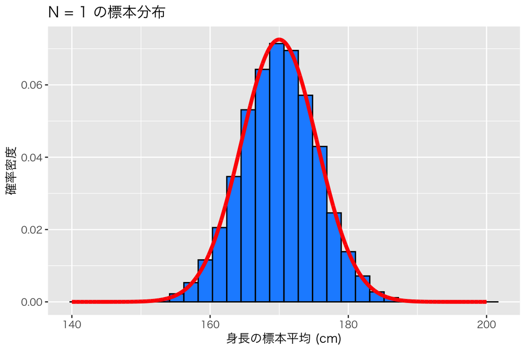

```r
df1$x <- seq(140, 200, length.out = nrow(df1))
df1$dens <- dnorm(df1$x, mean = mu, sd = sigma)
hist1_2 <- hist1 +
  geom_line(data = df1, aes(x = x, y = dens),
            color = "red", size = 1.5)
plot(hist1_2)
```

図を見る限り、標本平均の標本分布と、母集団の分布はとてもよく似ている。

統計量も確かめてみよう。

```r
mean(sim_1) # 標本平均の平均値
```

```
## [1] 170.0294
```

```r
sd(sim_1)   # 標本平均の標準偏差 = 標準誤差
```

```
## [1] 5.508017
```

このように、標本平均の平均値は母平均とほぼ同じであり、標本平均の標準偏差（これを平均値の**標準誤差 (standard errors: SE)** と呼ぶ）は、母標準偏差とほぼ同じである。

### 標本サイズ ($N$) が2のとき

標本サイズ $N = 2$ で、同様のシミュレーションを行ってみよう。 まず、$N$ を設定する。

```r
N <- 2
```

あとは、さきほどと同様のコマンドを実行すればよい。ただし、結果を上書きしないように、結果に異なる名前をつける。

```r
sim_2 <- rep(NA, n_sims)
for (i in 1:n_sims) {
  h <- rnorm(N, mean = mu, sd = sigma)
  sim_2[i] <- mean(h)  # sim_2 を使う
}
```

結果をヒストグラムにしてみよう。

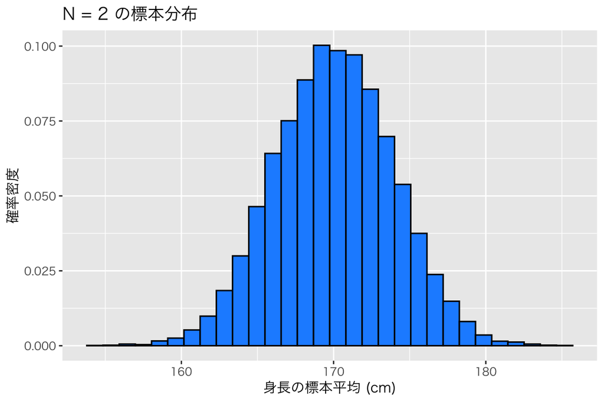

```r
df2 <- tibble(sim_2)
hist2 <- ggplot(df2, aes(x = sim_2, y = after_stat(density))) +
  geom_histogram(color = "black", fill = "dodgerblue") +
  labs(x = "身長の標本平均 (cm)",
       y = "確率密度",
       title = "N = 2 の標本分布")
plot(hist2)
```

このヒストグラムに、平均 170、標準偏差 5.5 の正規分布 ($\mbox{Normal}(170, 5.5)$) の確率密度曲線を重ね書きしてみよう。

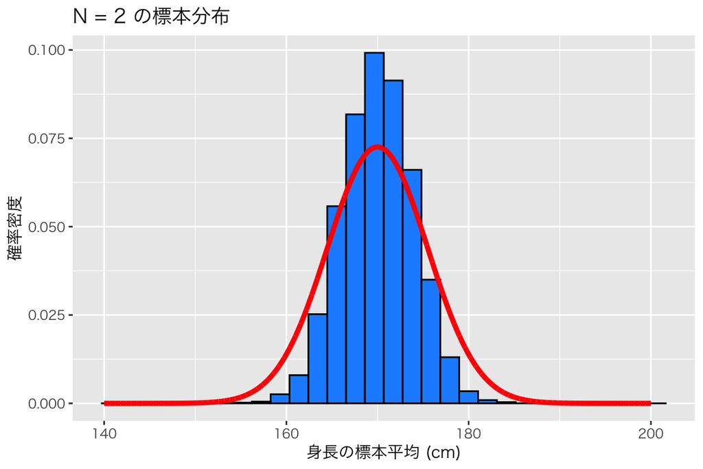

```r
hist2_2 <- hist2 +
  geom_line(data = df1, aes(x = x, y = dens),
            color = "red", size = 1.5)
plot(hist2_2)
```

先ほどとは異なり、標本平均の標本分布と、母集団の分布は少し異なる。標本分布の方が、母集団よりも狭い範囲に集まっていることがわかる。

統計量も確かめてみよう。

```r
mean(sim_2) # 標本平均の平均値
```

```
## [1] 170.0255
```

```r
sd(sim_2)   # 標本平均の標準偏差 = 標準誤差
```

```
## [1] 3.88809
```

上のシミュレーションと同様、標本平均の平均値は母平均とほぼ同じである。しかし、標本平均の標準偏差である**標準誤差 (standard errors; SE)** は、母標準偏差よりもかなり小さくなっていることがわかる。

理論的には、標準誤差は$母標準偏差/\sqrt{標本サイズ}$ になるはずである。確かめてみよう。

```r
sigma / sqrt(N)
```

```
## [1] 3.889087
```

これは、上で求めた標準誤差にほぼ一致する。

### 標本サイズ ($N$) が10のとき

標本サイズ $nN = 10$ で、同様のシミュレーションを行ってみよう。 まず、$N$ を設定する。

```r
N <- 10
```

あとは、先ほどと同様のコマンドを実行すればよい。ただし、結果を上書きしないように、結果に異なる名前をつける。

```r
sim_3 <- rep(NA, n_sims)
for (i in 1:n_sims) {
  h <- rnorm(N, mean = mu, sd = sigma)
  sim_3[i] <- mean(h)  # sim_3 を使う
}
```

結果をヒストグラムにしてみよう。

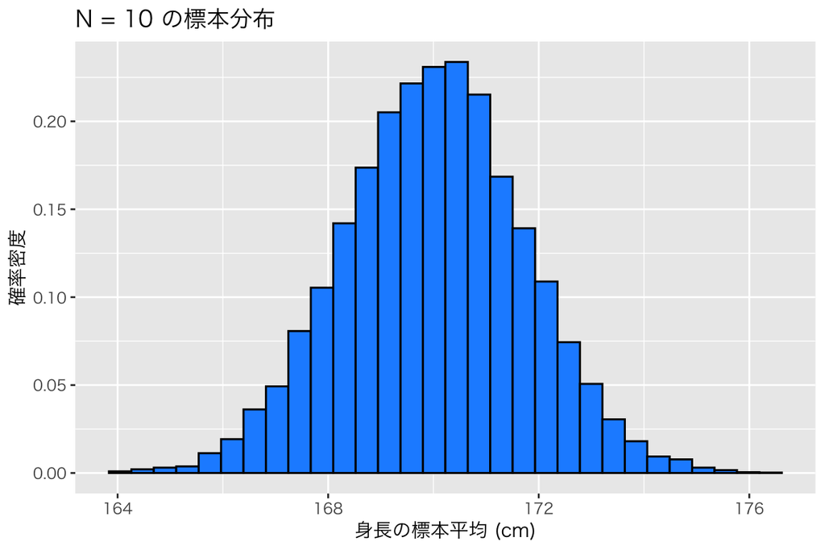

```r
df3 <- tibble(sim_3)
hist3 <- ggplot(df3, aes(x = sim_3, y = after_stat(density))) +
  geom_histogram(color = "black", fill = "dodgerblue") +
  labs(x = "身長の標本平均 (cm)",
       y = "確率密度",
       title = "N = 10 の標本分布")
plot(hist3)
```

このヒストグラムに、平均 170、標準偏差 5.5 の正規分布 ($\mbox{N}(170, 5.5)$) の確率密度曲線を重ね書きしてみよう。

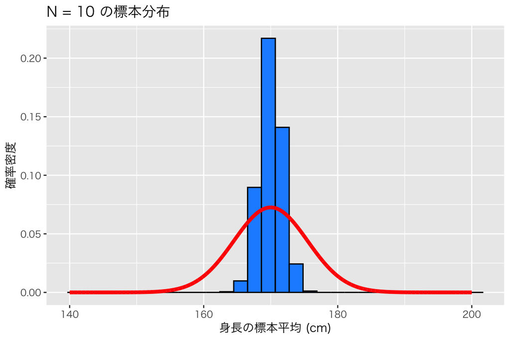

```r
hist3_2 <- hist3 +
  geom_line(data = df1, aes(x = x, y = dens),
            color = "red", size = 1.5)
plot(hist3_2)
```

標本分布がさらに狭い範囲に集まっていることがわかる。

統計量を確かめてみよう。

```r
mean(sim_3) # 標本平均の平均値
```

```
## [1] 170.0043
```

```r
sd(sim_3)   # 標本平均の標準偏差 = 標準誤差
```

```
## [1] 1.71496
```

先程と同様、標本平均の平均値は母平均とほぼ同じである。また、標本平均の標準偏差である**標準誤差 (standard errors; SE)** は、母標準偏差よりもより一層小さくなっていることがわかる。

理論的には、標準誤差は$母標準偏差/\sqrt{標本サイズ}$ になるはずである。確かめてみよう。

```r
sigma / sqrt(N)
```

```
## [1] 1.739253
```

これは、上で求めた標準誤差にほぼ一致する。

### 実習課題

標本サイズ $N$ を50、100にして、同様のシミュレーションを実行しよう。どのようなことがわかるか文章にまとめて整理しよう。

## 誤差の分布

標本平均の誤差は、
$$誤差 = 標本平均 - 母平均$$
と表すことができる。また、標本平均の平均値（期待値）は母平均に等しいので、
$$誤差 = 標本平均 - 標本平均の平均値$$
でも同じことである。

したがって、上で実行した3つのシミュレーション（それぞれ、$N = 1, 2, 10$）の誤差 `err_1`, `err_2`, `err_3` は、

```r
err_1 <- sim_1 - mean(sim_1)
err_2 <- sim_2 - mean(sim_2)
err_3 <- sim_3 - mean(sim_3)
```

である。さらに、それぞれを標準誤差で割ってみる。

```r
z1 <- err_1 / sd(sim_1)
z2 <- err_2 / sd(sim_2)
z3 <- err_3 / sd(sim_3)
```

平均値を引いて、それを標準偏差で割っているので、これは標準化 (standardization あるいは $z$化) である。

ここで、標準正規分布 $\mbox{Normal}(0, 1)$ の分布を図にしてみよう。

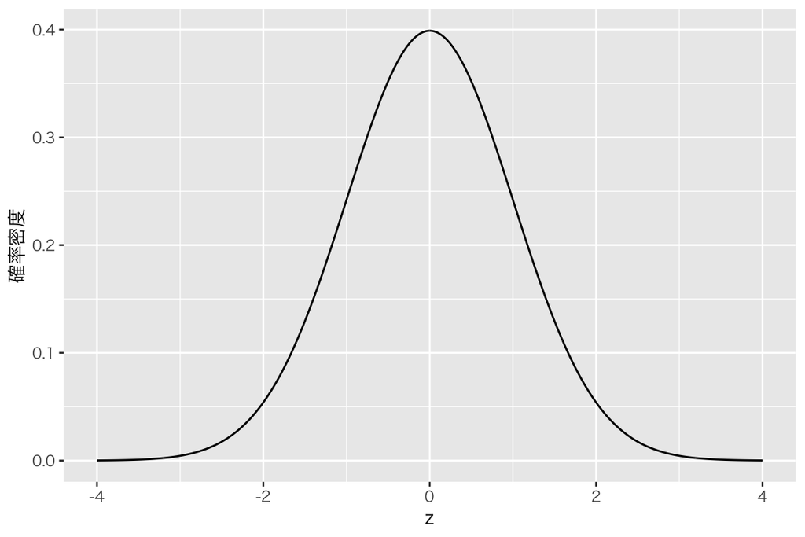

```r
df_nml <- tibble(z = seq(from = -4, to = 4, length.out = 1000))
df_nml$dens <- dnorm(df_nml$z,  mean = 0, sd = 1)
stdn <- ggplot(df_nml, aes(x = z, y = dens)) +
  geom_line() +
  labs(y = "確率密度")
plot(stdn)
```

この図に、先ほど計算した `z1`, `z2`, `z3` の分布を上書きしてみよう。確率密度 (density) を加えるため、`geom_density()` を使う。

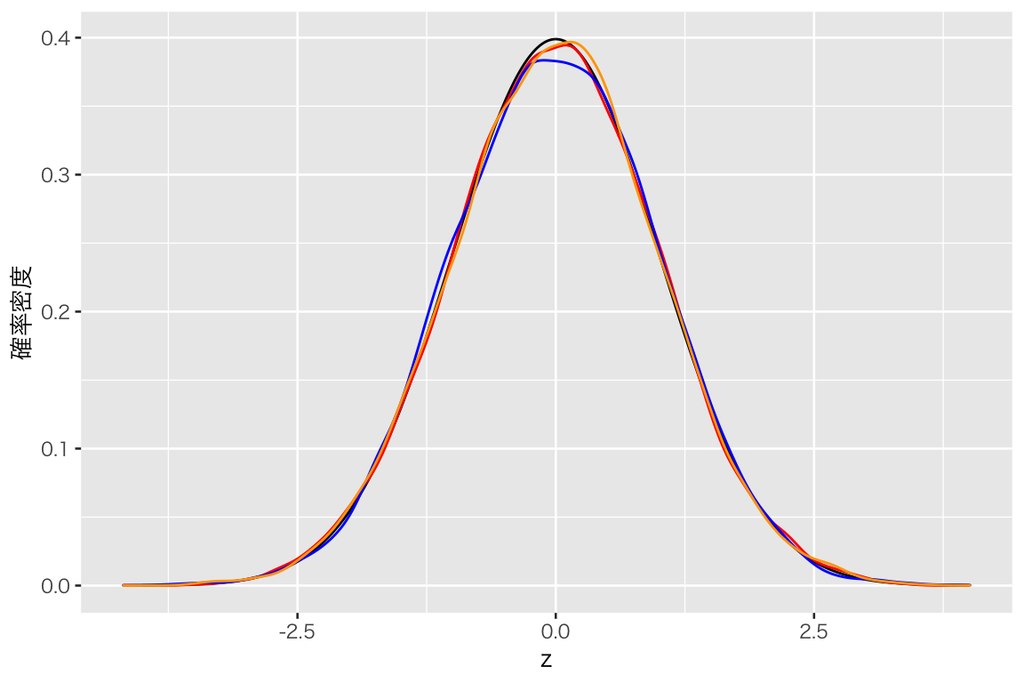

```r
df_z <- tibble(z1, z2, z3)
dens_lines <- stdn +
  geom_density(data = df_z,
               aes(x = z1, y = after_stat(density)),
               color = "red") +
  geom_density(data = df_z,
               aes(x = z2, y = after_stat(density)),
               color = "blue") +
  geom_density(data = df_z,
               aes(x = z3, y = after_stat(density)),
               color = "orange")
plot(dens_lines)
```

このように、標本平均を標準化すると、標準正規分布に似た分布が出てくる（4つの曲線が重なり合っていて区別が難しい）。よって、標準正規分布を利用した推定ができそうに見える（本当にできるかどうかは他の機会に解説する）。

授業の内容に戻る